# Project Preliminary Report

Matthew Blake and Donovan Roddy

# Introduction

Kan, Marni L., Yen-hsin Alice Cheng, Nancy S. Landale, and Susan M. McHale. 2010. “Longitudinal Predictors of Change in Number of Sexual Partners across Adolescence and Early Adulthood.” Journal of Adolescent Health 46 (1): 25–31. https://doi.org/10.1016/j.jadohealth.2009.05.002.

# Initial Modeling

## Tables

Summary Statistic Functions:

### Sex Count Summaries

The following tables compare the Sex Since Last Interview variable among several covariates:

| Table 1: Sex Sex | Table 1: Sex SSD_mean | Table 1: Sex SSD_median | Table 1: Sex SSD_sd | Table 1: Sex n |
| --- | --- | --- | --- | --- |
| Female | 127.212 | 50 | 209.737 | 29893 |
| Male | 118.938 | 48 | 208.948 | 30169 |

| Table 2: Race Race | Table 2: Race SSD_mean | Table 2: Race SSD_median | Table 2: Race SSD_sd | Table 2: Race n |
| --- | --- | --- | --- | --- |
| AAPI | 86.117 | 45.0 | 144.052 | 717 |
| AmerInd | 145.684 | 66.5 | 211.643 | 374 |
| Black | 98.851 | 25.0 | 201.069 | 15369 |
| Other | 139.834 | 50.0 | 236.904 | 6716 |
| White | 130.321 | 50.0 | 207.188 | 36430 |
| NA | 150.893 | 50.0 | 235.405 | 456 |

| Table 3: Ethnicity Ethnicity | Table 3: Ethnicity SSD_mean | Table 3: Ethnicity SSD_median | Table 3: Ethnicity SSD_sd | Table 3: Ethnicity n |
| --- | --- | --- | --- | --- |
| Hispanic | 143.102 | 50 | 236.146 | 12017 |
| Not_Hispanic | 118.042 | 50 | 201.824 | 48045 |

| Table 4: Region Region | Table 4: Region SSD_mean | Table 4: Region SSD_median | Table 4: Region SSD_sd | Table 4: Region n |
| --- | --- | --- | --- | --- |
| North Central | 123.818 | 50 | 205.019 | 12081 |
| Northeast | 120.441 | 50 | 202.817 | 8067 |
| South | 114.444 | 40 | 205.421 | 21781 |
| West | 135.395 | 50 | 217.900 | 11788 |
| NA | 131.569 | 50 | 221.369 | 6345 |

| Table 5: Rural_Urban Rural_Urban | Table 5: Rural_Urban SSD_mean | Table 5: Rural_Urban SSD_median | Table 5: Rural_Urban SSD_sd | Table 5: Rural_Urban n |
| --- | --- | --- | --- | --- |
| Rural | 121.795 | 50 | 203.859 | 11938 |
| Unknown | 111.824 | 50 | 191.960 | 2011 |
| Urban | 123.998 | 50 | 211.706 | 45746 |
| NA | 108.229 | 50 | 183.063 | 367 |

| Table 6: Marriage_Status Marriage_Status | Table 6: Marriage_Status SSD_mean | Table 6: Marriage_Status SSD_median | Table 6: Marriage_Status SSD_sd | Table 6: Marriage_Status n |
| --- | --- | --- | --- | --- |
| Cohabit | 196.256 | 100.0 | 256.834 | 9129 |
| Divorced | 184.579 | 100.0 | 257.097 | 1493 |
| Married | 184.768 | 100.0 | 243.663 | 12852 |
| Never Married | 82.897 | 27.0 | 166.356 | 33374 |
| Separated | 189.492 | 70.0 | 273.410 | 435 |
| Widowed | 149.636 | 67.5 | 189.926 | 22 |
| NA | 35.120 | 7.0 | 107.741 | 2757 |

| Table 7: Average High School GPA RoundedGPA | Table 7: Average High School GPA SSD_mean | Table 7: Average High School GPA SSD_median | Table 7: Average High School GPA SSD_sd | Table 7: Average High School GPA n |
| --- | --- | --- | --- | --- |
| 0 | 134.825 | 50 | 223.975 | 1982 |
| 1 | 116.469 | 45 | 204.791 | 2329 |
| 2 | 122.814 | 50 | 207.201 | 6710 |
| 3 | 102.528 | 50 | 161.477 | 12076 |
| 4 | 95.770 | 50 | 143.857 | 4441 |
| NA | 134.208 | 50 | 230.535 | 32524 |

| Table 8: Year year | Table 8: Year SSD_mean | Table 8: Year SSD_median | Table 8: Year SSD_sd | Table 8: Year n |
| --- | --- | --- | --- | --- |
| 1997 | 29.562 | 6 | 88.577 | 1242 |
| 1998 | 60.064 | 12 | 153.061 | 2294 |
| 1999 | 65.051 | 15 | 159.912 | 3161 |
| 2000 | 91.617 | 24 | 188.616 | 3988 |
| 2001 | 109.686 | 30 | 204.438 | 4619 |
| 2002 | 116.706 | 40 | 210.866 | 4809 |
| 2003 | 126.096 | 50 | 217.609 | 5052 |
| 2004 | 137.829 | 50 | 223.374 | 4054 |
| 2005 | 137.667 | 50 | 220.884 | 3927 |
| 2006 | 140.347 | 60 | 216.504 | 4341 |
| 2007 | 148.748 | 60 | 222.817 | 4332 |
| 2008 | 148.694 | 70 | 221.240 | 4505 |
| 2009 | 140.678 | 60 | 213.378 | 4690 |
| 2010 | 144.848 | 70 | 214.121 | 4570 |
| 2011 | 133.091 | 60 | 209.671 | 4478 |

| Table 9: Everything SSD_mean | Table 9: Everything SSD_median | Table 9: Everything SSD_sd | Table 9: Everything n |
| --- | --- | --- | --- |
| 123.056 | 50 | 209.38 | 60062 |

Region, Sex, and Year

### Partners Count Summaries

These tables compare the Number of Partners since Last Interview variable with several covariates

| Table 10: Region Region | Table 10: Region PLSI_mean | Table 10: Region PSLI_median | Table 10: Region PSLI_sd | Table 10: Region n |
| --- | --- | --- | --- | --- |
| North Central | 4.825 | 1 | 43.430 | 13796 |
| Northeast | 4.079 | 1 | 37.023 | 9717 |
| South | 4.955 | 1 | 43.984 | 25423 |
| West | 4.178 | 1 | 35.746 | 14219 |
| NA | 5.215 | 1 | 47.302 | 6466 |

| Table 11: Sex Sex | Table 11: Sex PLSI_mean | Table 11: Sex PSLI_median | Table 11: Sex PSLI_sd | Table 11: Sex n |
| --- | --- | --- | --- | --- |
| Female | 3.451 | 1 | 33.270 | 36044 |
| Male | 5.984 | 1 | 49.164 | 33577 |

| Table 12: Year year | Table 12: Year PLSI_mean | Table 12: Year PSLI_median | Table 12: Year PSLI_sd | Table 12: Year n |
| --- | --- | --- | --- | --- |
| 1997 | 2.625 | 1 | 4.700 | 5493 |
| 1998 | 2.428 | 1 | 4.246 | 5699 |
| 1999 | 5.217 | 1 | 50.472 | 6416 |
| 2000 | 3.118 | 1 | 31.282 | 6477 |
| 2001 | 3.775 | 1 | 31.281 | 5515 |
| 2002 | 3.657 | 1 | 32.800 | 5388 |
| 2003 | 6.757 | 1 | 56.960 | 5715 |
| 2004 | 6.479 | 1 | 46.720 | 5665 |
| 2005 | 6.180 | 1 | 54.647 | 5725 |
| 2006 | 4.238 | 1 | 37.046 | 5936 |
| 2007 | 5.819 | 1 | 52.523 | 5833 |
| 2008 | 5.753 | 1 | 50.595 | 5739 |
| 2010 | 1.000 | 1 | 0.000 | 3 |
| 2013 | 1.000 | 1 | 0.000 | 7 |
| 2015 | 2.500 | 2 | 1.179 | 10 |

## Graphs

[figure not shown]

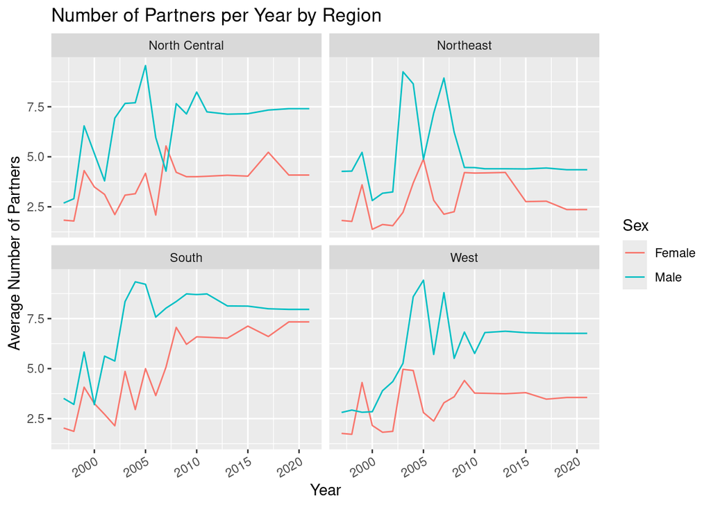

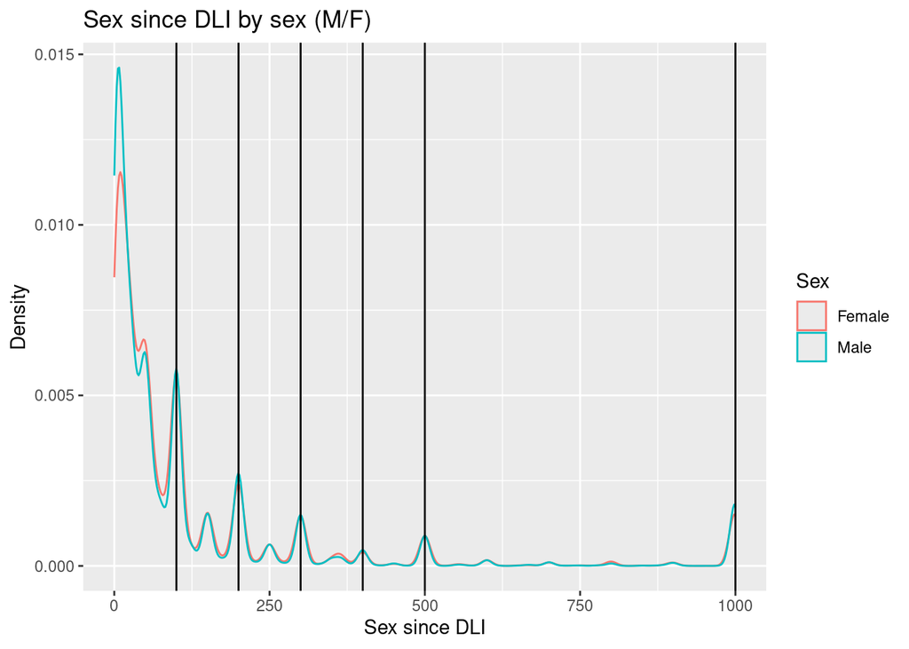

# Modeling

## Sex Since DLI

|  | npar | AIC | BIC | logLik | deviance | Chisq | Df | Pr(>Chisq) |
| --- | --- | --- | --- | --- | --- | --- | --- | --- |
| glmer0 | 2 | 6421724 | 6421742 | -3210860 | 6421720 | NA | NA | NA |
| glmer1 | 3 | 6421726 | 6421753 | -3210860 | 6421720 | 0.07123641 | 1 | 0.789545 |

|  | Estimate | Std. Error | z value | Pr(>\|z\|) |
| --- | --- | --- | --- | --- |
| (Intercept) | 2.627627876 | 0.05298660 | 49.5904245 | 0.0000000 |
| Avg_GPA | 0.005294302 | 0.01947221 | 0.2718901 | 0.7857065 |

This test shows that average HS GPA is not significant by itself. This gives a preliminary answer to our question “Is Avg GPA a significant predictor of number of sexual encounters?”

However, this basic model is a significant oversimplification of the picture, because people change over time. Our second model will account for the age and marriage / cohabitation status at the time of interview. The addition of these level one variables will hopefully allow us to isolate any impact the avg_GPA might have.

|  | Estimate | Std. Error | z value | Pr(>\|z\|) |
| --- | --- | --- | --- | --- |
| (Intercept) | 4.38096702 | 0.083421836 | 52.515831 | 0.000000e+00 |
| Avg_GPA | 0.13789543 | 0.030716194 | 4.489340 | 7.144430e-06 |
| age | -0.04973936 | 0.002772598 | -17.939620 | 5.784895e-72 |
| Marriage_StatusDivorced | -0.14501442 | 0.003234315 | -44.836202 | 0.000000e+00 |
| Marriage_StatusMarried | -0.01472867 | 0.001893820 | -7.777225 | 7.413281e-15 |
| Marriage_StatusNever Married | -0.78853352 | 0.001548146 | -509.340396 | 0.000000e+00 |
| Marriage_StatusSeparated | -0.18453319 | 0.004894852 | -37.699445 | 0.000000e+00 |
| Marriage_StatusWidowed | -0.44917847 | 0.014708844 | -30.537986 | 8.164757e-205 |
| Avg_GPA:age | -0.00616853 | 0.001018896 | -6.054133 | 1.411759e-09 |

| grp | var1 | var2 | vcov | sdcor |
| --- | --- | --- | --- | --- |
| PUBID | (Intercept) | NA | 3.531516130 | 1.87923286 |
| PUBID | age | NA | 0.003766783 | 0.06137412 |
| PUBID | (Intercept) | age | -0.093634103 | -0.81183571 |

Level 1:

$$\log(\frac{\lambda_{ij}}{interview\_dist_{ij}}) =
a_i + b_iAge_{ij}$$
Level 2:
$$a_i =
\alpha_0 + \alpha_1Avg\_GPA_i + \alpha_2Marriage\_Status_{ij} +
u_i$$
$$b_i = \beta_0 +
\beta_1Avg\_GPA +v_i$$
Composite Model
$$\log(\frac{\lambda_{ij}}{interview\_dist_{ij}}) =
\alpha_0 + \alpha_1Avg\_GPA_i + \alpha_2Marriage\_Status_{ij} + u_i +
(\beta_0 + \beta_1Avg\_GPA +v_i)Age_{ij}$$

Interpretation of Coefficients:

$\alpha_0 = 4.38$: According to our model, a cohabitating 0-year old with a 0.0 high school GPA is expected to have had an average of 4.38 sexual encounters over the past year.

$\alpha_1 = 0.138$: Holding marriage status constant, a 0-year-old individual is estimated to have had 0.138 more sexual encounters in the past year for each addition point in his or her high school GPA.

$\beta_0 = -0.050:$ Holding marriage status constant, among individuals with a 0.0 high school GPA an increase of one year in age is associated with a decrease by 0.050 of number of sexual encounters in the past year.

$\beta_1 = -0.00617:$ Holding marriage status constant, for each point of GPA in high school an individual has, an increase in age of one year is associated with a further decrease of 0.00617 sexual encounters in the past year.

$\sigma_u = 1.879:$ For a given individual, the mean of the number of sexual encounters in each year for which they have responded, is expected to differ from the average of such means of all individuals by 1.879 sexual encounters.

$\sigma_v = 0.0614:$ For each year of a respondent’s age, their number of sexual encounters in the past year is expected to differ from their average number of sexual encounters for all of their years, by 0.0614 sexual encounters.

$\rho_{uv} = -0.81:$ The correlation between the random variables $u_i$ and $v_i$ is -0.81. This means that in general, a higher variance in number of sexual encounters early in one’s life will tend to decrease as a person’s age increases, and a low variance in number of sexual encounters early in one’s life will tend to increase.

## Num_Partners

|  | Estimate | Std. Error | z value | Pr(>\|z\|) |
| --- | --- | --- | --- | --- |
| (Intercept) | -0.04703951 | 0.056065573 | -0.8390087 | 4.014644e-01 |
| RegionNortheast | -0.35249437 | 0.038445060 | -9.1687818 | 4.783944e-20 |
| RegionSouth | 0.01170941 | 0.030039073 | 0.3898060 | 6.966800e-01 |
| RegionWest | 0.19458294 | 0.032368604 | 6.0114714 | 1.838469e-09 |
| SexMale | 0.20405510 | 0.030245467 | 6.7466340 | 1.513143e-11 |
| year_center | 0.05511690 | 0.003924138 | 14.0456049 | 8.196557e-45 |
| Avg_GPA | -0.08163602 | 0.014716412 | -5.5472776 | 2.901519e-08 |
| relationshipNot Cohabit | 0.31593275 | 0.013116282 | 24.0870653 | 3.415597e-128 |

| grp | var1 | var2 | vcov | sdcor |
| --- | --- | --- | --- | --- |
| PUBID | (Intercept) | NA | 2.08452891 | 1.4437898 |
| PUBID | year_center | NA | 0.03498873 | 0.1870527 |
| PUBID | (Intercept) | year_center | -0.22619612 | -0.8375623 |

Hlavac, Marek (2022). stargazer: Well-Formatted Regression and Summary Statistics Tables. R package version 5.2.3. https://CRAN.R-project.org/package=stargazer

Level 1:

$$\log(\frac{\lambda_{ij}}{interview\_dist_{ij}}) =
a_i + b_iYear_{ij} +c_iRegion_{ij} + d_iRelationship_{ij}$$
Level 2:

$$a_i = \alpha_0 + \alpha_1Sex_i +
\alpha_2Avg\_GPA_i + u_i$$

$$b_i = \beta_0 +v_i$$
$$c_i = \gamma_0$$
$$d_i = \delta_0$$
Composite Model
$$\log(\frac{\lambda_{ij}}{interview\_dist_{ij}})
= \alpha_0 + \alpha_1Sex_i + \alpha_2Avg\_GPA_i + u_i +
\beta_0Year_{ij} + v_iYear_{ij} +\gamma_0Region_{ij} +
\delta_0Relationship_{ij}$$

$\alpha_1$ On average, after adjusting for the year, average GPA, Region, and whether they were co-habitating with a partner, men have 0.2 more sexual partners than women.

$\delta_0$: On average, after adjusting for time, the sex, average GPA, Region the average respondent who is not co-habitating with a partner is expected to report about 1.37 more sexual partners than those who are co-habitating.

$\sigma_u$ The respondent to respondent St. Deviation in number of sexual partners for those in the women in the north central who were not cohabitating with a partner is 1.4438

$\sigma_v$ = the respondent to respondent St. Deviation of the slope on year is 0.1871, after adjusting for their age, average GPA, sex, region, and if there were co-habitating with a partner.

# Data Limitations

The Data had a number of restrictions. Firstly, the data was self reported, so there are many possibilities for individuals to not accurately report. This has been noted to be common in prior studies of sexual self reporting surveys for a number of speculated reasons (Hallfors et al. 2002). The self-reporting issues are particularly evident in the sexual frequency data, where the distribution indicates clear spikes in numbers in the 5 or 10s place. Considering this is likely not something that people keep track of explicitly, and the variation in the years between interviews on this questionnaire, It is probably that the variation in sexual frequency is actually under reported. Finally, a number of respondents were simply not asked either of the questions and had to be dropped from the study. Considering the private nature of reporting on sexual behavior, addressing this particular challenge is difficult to overcome.

Regarding model assumptions, for the model on sexual partners, the model we ran struggled with overdispersion. This seems likely as there was a significantly large number of 1s reported. This could be due to the reasons listed above. As a result, these limitations could be biasing the effects and overestimating the associations of different variables, including GPA. The mlm package doesn’t have a negative binomial package, which would likely be a better fit for this data.

In particular, a number of respondents in the National Longitudinal Survey of Youth 97 did not have any responses recorded for sexual partners; this is likely due to other reporting issues with self reported data and likely could skew the results.

# Methods

The National Longitudinal Study of Youth (1997) is a study which has followed American individuals born between 1980 and 1984, giving yearly interviews from 1997 to 2021. The questions were administered via a CAPI (Computer-Assisted Personal Interview) instrument, which helps guide the respondent through the process, and to ensure that invalid answers are not given. Sometimes, these tests are administered with an interview present in person, but this is not always the case. Some of the questions are self-administered.

Respondents were offered $10-20 per round of interviewing they participated in. Other incentives were sometimes offered.

# Audience

The intended audience for this report is for a sociology journal that explores trends in sexual relationships. The goal would be an academic article about the data analysis involved in exploring social-sexual behavior. Our intention is to write to an audience who may have more knowledge about the literature and background in studying sexual relationships.

# Sources

Kan, Marni L., Yen-hsin Alice Cheng, Nancy S. Landale, and Susan M. McHale. 2010. “Longitudinal Predictors of Change in Number of Sexual Partners across Adolescence and Early Adulthood.” Journal of Adolescent Health 46 (1): 25–31. https://doi.org/10.1016/j.jadohealth.2009.05.002.

Our data was collected from the National Longitudinal Survey of Youth– 1997. This survey tracked individuals born from 1980 to 1984. https://www.nlsinfo.org/content/cohorts/nlsy97